# Plant_1_Linreg_Period

tanchuanxin

11/1/2021

# Setup

We will perform the necessary imports, and change the working directory based on the user

```r
knitr::opts_chunk$set(echo = TRUE)
library(data.table)
```

```r
library(rpart)
library(rpart.plot)
library(car)
library(corrplot)
library(tidyverse)
library(caTools)
library(ggplot2)
library(lubridate)
library(TTR)
library(tsbox)
# setwd("C:/Users/matth/Desktop/Course Materials for Stu/AY21 Team Assignment and Project")
setwd("C:/Users/user/Documents/Github/project-MAI") # chuanxin's wd
set.seed(2021)
seed = 2021

# load dataset
plant_1.dt <- fread("Plant_1_Data.csv")

# convert some features into factors where relevant
plant_1.dt$SOURCE_KEY <- factor(plant_1.dt$SOURCE_KEY)
plant_1.dt$DOTW <- factor(plant_1.dt$DOTW)
plant_1.dt$TIME <- factor(plant_1.dt$TIME)
plant_1.dt$DATE <- factor(plant_1.dt$DATE)

head(plant_1.dt)
```

```
##          DATE  TIME PLANT_ID      SOURCE_KEY DC_POWER AC_POWER DAILY_YIELD
## 1: 2020-05-16 06:15  4135001 1BY6WEcLGh8j5v7 309.0000 29.86250    3.875000
## 2: 2020-05-16 06:15  4135001 1IF53ai7Xc0U56Y 353.1429 34.15714    3.714286
## 3: 2020-05-16 06:15  4135001 3PZuoBAID5Wc2HD 346.5714 33.48571    3.714286
## 4: 2020-05-16 06:15  4135001 7JYdWkrLSPkdwr4 349.0000 33.72500    3.750000
## 5: 2020-05-16 06:15  4135001 McdE0feGgRqW7Ca 348.2500 33.67500    4.750000
## 6: 2020-05-16 06:15  4135001 VHMLBKoKgIrUVDU 357.3750 34.52500    4.000000
##    TOTAL_YIELD     DOTW PERIOD_YIELD      DATE_TIME AMBIENT_TEMPERATURE
## 1:     6265317 Saturday        3.875 16/5/2020 6:15               21.86
## 2:     6190006 Saturday        3.714 16/5/2020 6:15               21.86
## 3:     6994037 Saturday        3.714 16/5/2020 6:15               21.86
## 4:     7609080 Saturday        3.750 16/5/2020 6:15               21.86
## 5:     7165440 Saturday        4.464 16/5/2020 6:15               21.86
## 6:     7212670 Saturday        4.000 16/5/2020 6:15               21.86
##    MODULE_TEMPERATURE IRRADIATION Relative Humidity (%) Pressure (hPa)
## 1:              20.43  0.02363374                 46.34         997.31
## 2:              20.43  0.02363374                 46.34         997.31
## 3:              20.43  0.02363374                 46.34         997.31
## 4:              20.43  0.02363374                 46.34         997.31
## 5:              20.43  0.02363374                 46.34         997.31
## 6:              20.43  0.02363374                 46.34         997.31
##    Wind speed (m/s) Wind direction Rainfall (kg/m2)
## 1:             3.27         290.15            8e-06
## 2:             3.27         290.15            8e-06
## 3:             3.27         290.15            8e-06
## 4:             3.27         290.15            8e-06
## 5:             3.27         290.15            8e-06
## 6:             3.27         290.15            8e-06
```

# Load in the data

Perform some cleaning on the data

```r
# remove some of the extra features that we have
linreg_period_yield.dt <- subset(plant_1.dt, select = -c(DATE, TIME, PLANT_ID, DOTW, DATE_TIME, DAILY_YIELD, TOTAL_YIELD, DC_POWER, AC_POWER))

summary(linreg_period_yield.dt)
```

```
##            SOURCE_KEY     PERIOD_YIELD    AMBIENT_TEMPERATURE
##  bvBOhCH3iADSZry: 1538   Min.   :  0.00   Min.   :20.84
##  1BY6WEcLGh8j5v7: 1537   1st Qu.: 36.42   1st Qu.:25.13
##  7JYdWkrLSPkdwr4: 1524   Median :133.59   Median :27.52
##  VHMLBKoKgIrUVDU: 1524   Mean   :132.10   Mean   :27.50
##  ih0vzX44oOqAx2f: 1522   3rd Qu.:211.93   3rd Qu.:29.63
##  ZnxXDlPa8U1GXgE: 1522   Max.   :374.00   Max.   :35.25
##  (Other)        :24127
##  MODULE_TEMPERATURE  IRRADIATION     Relative Humidity (%) Pressure (hPa)
##  Min.   :18.73      Min.   :0.0000   Min.   :30.36         Min.   : 990.2
##  1st Qu.:27.50      1st Qu.:0.1072   1st Qu.:56.96         1st Qu.: 992.6
##  Median :39.04      Median :0.3902   Median :69.77         Median : 993.9
##  Mean   :38.67      Mean   :0.4003   Mean   :66.92         Mean   : 994.2
##  3rd Qu.:47.99      3rd Qu.:0.6383   3rd Qu.:77.91         3rd Qu.: 995.4
##  Max.   :65.55      Max.   :1.2217   Max.   :88.66         Max.   :1000.5
##
##  Wind speed (m/s) Wind direction   Rainfall (kg/m2)
##  Min.   :0.940    Min.   :  2.31   Min.   :0.000000
##  1st Qu.:3.600    1st Qu.:250.33   1st Qu.:0.000306
##  Median :4.320    Median :280.09   Median :0.003183
##  Mean   :4.492    Mean   :271.58   Mean   :0.021166
##  3rd Qu.:5.490    3rd Qu.:295.07   3rd Qu.:0.022924
##  Max.   :8.040    Max.   :358.74   Max.   :0.184701
##
```

# Removing correlated variables

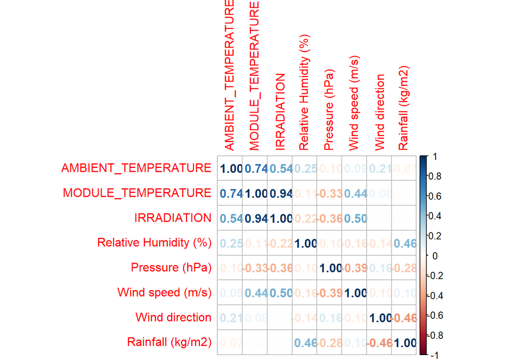

```r
M = cor(subset(linreg_period_yield.dt, select = -c(PERIOD_YIELD, SOURCE_KEY)))
corrplot(M, method = "number")
```

```r
# We discover that MODULE_TEMPERATURE and IRRADIATION are highly correlated at 0.94


m1 <- lm(PERIOD_YIELD ~ .-SOURCE_KEY, data = linreg_period_yield.dt)
summary(m1)
```

```
##
## Call:
## lm(formula = PERIOD_YIELD ~ . - SOURCE_KEY, data = linreg_period_yield.dt)
##
## Residuals:
##     Min      1Q  Median      3Q     Max
## -350.75   -8.52   -1.39    9.32  255.23
##
## Coefficients:
##                           Estimate Std. Error t value Pr(>|t|)
## (Intercept)             -1.789e+03  7.349e+01 -24.341  < 2e-16 ***
## AMBIENT_TEMPERATURE     -5.929e+00  9.931e-02 -59.701  < 2e-16 ***
## MODULE_TEMPERATURE       6.334e+00  5.411e-02 117.069  < 2e-16 ***
## IRRADIATION              1.132e+02  1.575e+00  71.872  < 2e-16 ***
## `Relative Humidity (%)`  2.285e-01  1.372e-02  16.653  < 2e-16 ***
## `Pressure (hPa)`         1.786e+00  7.386e-02  24.187  < 2e-16 ***
## `Wind speed (m/s)`       1.757e+00  1.162e-01  15.121  < 2e-16 ***
## `Wind direction`        -1.772e-02  3.525e-03  -5.025 5.05e-07 ***
## `Rainfall (kg/m2)`      -3.128e+01  4.419e+00  -7.078 1.49e-12 ***
## ---
## Signif. codes:  0 '***' 0.001 '**' 0.01 '*' 0.05 '.' 0.1 ' ' 1
##
## Residual standard error: 22.43 on 33285 degrees of freedom
## Multiple R-squared:  0.9478, Adjusted R-squared:  0.9478
## F-statistic: 7.554e+04 on 8 and 33285 DF,  p-value: < 2.2e-16
```

```r
vif(m1)
```

```
##     AMBIENT_TEMPERATURE      MODULE_TEMPERATURE             IRRADIATION
##                6.232462               26.871987               15.531231
## `Relative Humidity (%)`        `Pressure (hPa)`      `Wind speed (m/s)`
##                2.128630                1.408281                1.536325
##        `Wind direction`      `Rainfall (kg/m2)`
##                1.333093                1.792704
```

```r
# we see that MODULE_TEMPERATURE has the highest VIF value of 26.9 > 10, we try and exclude that first

m2 <- lm(PERIOD_YIELD ~ .-SOURCE_KEY -MODULE_TEMPERATURE, data = linreg_period_yield.dt)
summary(m2)
```

```
##
## Call:
## lm(formula = PERIOD_YIELD ~ . - SOURCE_KEY - MODULE_TEMPERATURE,
##     data = linreg_period_yield.dt)
##
## Residuals:
##     Min      1Q  Median      3Q     Max
## -362.99  -11.03   -2.39   10.31  254.99
##
## Coefficients:
##                           Estimate Std. Error t value Pr(>|t|)
## (Intercept)             -4.057e+02  8.618e+01  -4.707 2.52e-06 ***
## AMBIENT_TEMPERATURE      3.347e+00  7.114e-02  47.050  < 2e-16 ***
## IRRADIATION              2.806e+02  7.866e-01 356.740  < 2e-16 ***
## `Relative Humidity (%)` -1.482e-01  1.585e-02  -9.350  < 2e-16 ***
## `Pressure (hPa)`         3.378e-01  8.651e-02   3.905 9.44e-05 ***
## `Wind speed (m/s)`       3.245e+00  1.372e-01  23.650  < 2e-16 ***
## `Wind direction`        -2.697e-02  4.187e-03  -6.440 1.21e-10 ***
## `Rainfall (kg/m2)`       1.078e+01  5.233e+00   2.059   0.0395 *
## ---
## Signif. codes:  0 '***' 0.001 '**' 0.01 '*' 0.05 '.' 0.1 ' ' 1
##
## Residual standard error: 26.65 on 33286 degrees of freedom
## Multiple R-squared:  0.9263, Adjusted R-squared:  0.9263
## F-statistic: 5.977e+04 on 7 and 33286 DF,  p-value: < 2.2e-16
```

```r
vif(m2)
```

```
##     AMBIENT_TEMPERATURE             IRRADIATION `Relative Humidity (%)`
##                2.265214                2.742249                2.011574
##        `Pressure (hPa)`      `Wind speed (m/s)`        `Wind direction`
##                1.368753                1.517930                1.332423
##      `Rainfall (kg/m2)`
##                1.780858
```

```r
# now all the VIF values are <10



# With selected features, develop model on trainset
train <- sample.split(Y = linreg_period_yield.dt$PERIOD_YIELD, SplitRatio = 0.7)
trainset <- subset(linreg_period_yield.dt, train == T)
testset <- subset(linreg_period_yield.dt, train == F)

# Checking the distribution of Y is similar in trainset vs testset.
summary(trainset$PERIOD_YIELD)
```

```
##    Min. 1st Qu.  Median    Mean 3rd Qu.    Max.
##    0.00   37.07  133.82  132.87  213.22  374.00
```

```r
summary(testset$PERIOD_YIELD)
```

```
##    Min. 1st Qu.  Median    Mean 3rd Qu.    Max.
##    0.00   35.35  132.74  130.19  209.08  328.16
```

```r
# yes, similar enough

# create model
m3 <- lm(PERIOD_YIELD ~ .-SOURCE_KEY -MODULE_TEMPERATURE, data = trainset)
summary(m3)
```

```
##
## Call:
## lm(formula = PERIOD_YIELD ~ . - SOURCE_KEY - MODULE_TEMPERATURE,
##     data = trainset)
##
## Residuals:
##     Min      1Q  Median      3Q     Max
## -363.43  -11.14   -2.47   10.19  254.60
##
## Coefficients:
##                           Estimate Std. Error t value Pr(>|t|)
## (Intercept)             -4.018e+02  1.033e+02  -3.889 0.000101 ***
## AMBIENT_TEMPERATURE      3.297e+00  8.514e-02  38.726  < 2e-16 ***
## IRRADIATION              2.811e+02  9.362e-01 300.253  < 2e-16 ***
## `Relative Humidity (%)` -1.531e-01  1.898e-02  -8.065 7.65e-16 ***
## `Pressure (hPa)`         3.365e-01  1.037e-01   3.245 0.001177 **
## `Wind speed (m/s)`       3.027e+00  1.640e-01  18.458  < 2e-16 ***
## `Wind direction`        -2.746e-02  5.016e-03  -5.475 4.42e-08 ***
## `Rainfall (kg/m2)`       1.117e+01  6.270e+00   1.782 0.074835 .
## ---
## Signif. codes:  0 '***' 0.001 '**' 0.01 '*' 0.05 '.' 0.1 ' ' 1
##
## Residual standard error: 26.95 on 23728 degrees of freedom
## Multiple R-squared:  0.9254, Adjusted R-squared:  0.9253
## F-statistic: 4.203e+04 on 7 and 23728 DF,  p-value: < 2.2e-16
```

```r
# residuals(m3)

# Residuals = Error = Actual - Model Predicted
RMSE.m3.train <- sqrt(mean(residuals(m3)^2))  # RMSE on trainset based on m3 model.
summary(abs(residuals(m3)))  # Check Min Abs Error and Max Abs Error.
```

```
##     Min.  1st Qu.   Median     Mean  3rd Qu.     Max.
##   0.0027   5.1574  10.7917  17.0814  21.2330 363.4308
```

```r
# Apply model from trainset to predict on testset.
predict.m3.test <- predict(m3, newdata = testset)
testset.error <- testset$PERIOD_YIELD - predict.m3.test

# Testset Errors
RMSE.m3.test <- sqrt(mean(testset.error^2))
summary(abs(testset.error))
```

```
##     Min.  1st Qu.   Median     Mean  3rd Qu.     Max.
##   0.0014   5.1503  10.6067  16.6640  21.0847 363.4308
```

```r
# mean testset error is 16.6640
```

# Check by individual SOURCE_KEY

The full datasets consists of many panels, and when different data are brought together, it might display some characteristics that were otherwise not present. We will look at each of the panels individually to see if we find anything interesting

```r
for (level in levels(linreg_period_yield.dt$SOURCE_KEY)) {
  source_key_period_yield.dt <- filter(linreg_period_yield.dt, SOURCE_KEY==level) %>%
    subset(, -c(SOURCE_KEY))

  m4 <- lm(PERIOD_YIELD ~ .-MODULE_TEMPERATURE, data = source_key_period_yield.dt)
  paste("levels: ", as.character(level))
  print(summary(m4))
  print(vif(m4))
}
```

```
##
## Call:
## lm(formula = PERIOD_YIELD ~ . - MODULE_TEMPERATURE, data = source_key_period_yield.dt)
##
## Residuals:
##      Min       1Q   Median       3Q      Max
## -280.447  -12.032   -1.885   13.915  210.140
##
## Coefficients:
##                           Estimate Std. Error t value Pr(>|t|)
## (Intercept)             -124.45560  502.27502  -0.248  0.80433
## AMBIENT_TEMPERATURE        3.72934    0.41423   9.003  < 2e-16 ***
## IRRADIATION              247.91147    4.59112  53.998  < 2e-16 ***
## `Relative Humidity (%)`   -0.17778    0.09237  -1.925  0.05445 .
## `Pressure (hPa)`           0.06115    0.50421   0.121  0.90348
## `Wind speed (m/s)`         4.40795    0.79864   5.519 3.99e-08 ***
## `Wind direction`          -0.06728    0.02433  -2.765  0.00576 **
## `Rainfall (kg/m2)`      -294.37530   30.65841  -9.602  < 2e-16 ***
## ---
## Signif. codes:  0 '***' 0.001 '**' 0.01 '*' 0.05 '.' 0.1 ' ' 1
##
## Residual standard error: 33.36 on 1529 degrees of freedom
## Multiple R-squared:  0.873,  Adjusted R-squared:  0.8724
## F-statistic:  1501 on 7 and 1529 DF,  p-value: < 2.2e-16
##
##     AMBIENT_TEMPERATURE             IRRADIATION `Relative Humidity (%)`
##                2.247452                2.779225                2.009368
##        `Pressure (hPa)`      `Wind speed (m/s)`        `Wind direction`
##                1.363675                1.526168                1.329900
##      `Rainfall (kg/m2)`
##                1.777218
##
## Call:
## lm(formula = PERIOD_YIELD ~ . - MODULE_TEMPERATURE, data = source_key_period_yield.dt)
##
## Residuals:
##      Min       1Q   Median       3Q      Max
## -166.673  -10.778   -2.104    9.339  246.692
##
## Coefficients:
```

[output cut: 627 more lines]

```
## `Wind direction`          -0.01568    0.01750  -0.896  0.37047
## `Rainfall (kg/m2)`        58.30433   21.83570   2.670  0.00766 **
## ---
## Signif. codes:  0 '***' 0.001 '**' 0.01 '*' 0.05 '.' 0.1 ' ' 1
##
## Residual standard error: 23.69 on 1500 degrees of freedom
## Multiple R-squared:  0.9424, Adjusted R-squared:  0.9421
## F-statistic:  3504 on 7 and 1500 DF,  p-value: < 2.2e-16
##
##     AMBIENT_TEMPERATURE             IRRADIATION `Relative Humidity (%)`
##                2.266702                2.745454                2.000781
##        `Pressure (hPa)`      `Wind speed (m/s)`        `Wind direction`
##                1.376225                1.517461                1.334321
##      `Rainfall (kg/m2)`
##                1.782095
```

# Removing features

We see that when considering individual inverters, what stands out is that only three variables are consistently highly significant: AmBIENT_TEMPERATURE, IRRADIATION, Wind speed (m/s)… the rest other variables can be considered for removal.

We will remove rainfall first, which shows the least statistically significant result

```r
# find a smaller subset of data - we can remove rainfall, since it is the least significant out of all the variables
linreg_period_yield_selected.dt <- subset(linreg_period_yield.dt, select = -c(MODULE_TEMPERATURE, `Rainfall (kg/m2)`))

# With selected features, develop model on trainset
train <- sample.split(Y = linreg_period_yield_selected.dt$PERIOD_YIELD, SplitRatio = 0.7)
trainset <- subset(linreg_period_yield_selected.dt, train == T)
testset <- subset(linreg_period_yield_selected.dt, train == F)

# Checking the distribution of Y is similar in trainset vs testset.
summary(trainset$PERIOD_YIELD)
```

```
##    Min. 1st Qu.  Median    Mean 3rd Qu.    Max.
##    0.00   37.07  133.82  132.87  213.22  374.00
```

```r
summary(testset$PERIOD_YIELD)
```

```
##    Min. 1st Qu.  Median    Mean 3rd Qu.    Max.
##    0.00   35.35  132.74  130.19  209.08  328.16
```

```r
# yes, similar enough

# create model
m5 <- lm(PERIOD_YIELD ~ .-SOURCE_KEY, data = trainset)
summary(m5)
```

```
##
## Call:
## lm(formula = PERIOD_YIELD ~ . - SOURCE_KEY, data = trainset)
##
## Residuals:
##     Min      1Q  Median      3Q     Max
## -363.21  -10.99   -2.48   10.20  254.46
##
## Coefficients:
##                           Estimate Std. Error t value Pr(>|t|)
## (Intercept)             -4.150e+02  1.010e+02  -4.109 3.98e-05 ***
## AMBIENT_TEMPERATURE      3.173e+00  8.182e-02  38.783  < 2e-16 ***
## IRRADIATION              2.820e+02  9.108e-01 309.647  < 2e-16 ***
## `Relative Humidity (%)` -1.113e-01  1.631e-02  -6.824 9.10e-12 ***
## `Pressure (hPa)`         3.507e-01  1.014e-01   3.457 0.000547 ***
## `Wind speed (m/s)`       3.160e+00  1.620e-01  19.512  < 2e-16 ***
## `Wind direction`        -3.136e-02  4.651e-03  -6.742 1.59e-11 ***
## ---
## Signif. codes:  0 '***' 0.001 '**' 0.01 '*' 0.05 '.' 0.1 ' ' 1
##
## Residual standard error: 26.6 on 23729 degrees of freedom
## Multiple R-squared:  0.9273, Adjusted R-squared:  0.9273
## F-statistic: 5.044e+04 on 6 and 23729 DF,  p-value: < 2.2e-16
```

```r
# residuals(m5)

# Residuals = Error = Actual - Model Predicted
RMSE.m5.train <- sqrt(mean(residuals(m5)^2))  # RMSE on trainset based on m5 model.
summary(abs(residuals(m5)))  # Check Min Abs Error and Max Abs Error.
```

```
##     Min.  1st Qu.   Median     Mean  3rd Qu.     Max.
##   0.0022   5.1156  10.7236  17.0120  21.2151 363.2129
```

```r
# Apply model from trainset to predict on testset.
predict.m5.test <- predict(m5, newdata = testset)
testset.error <- testset$PERIOD_YIELD - predict.m5.test

# Testset Errors
RMSE.m5.test <- sqrt(mean(testset.error^2))
summary(abs(testset.error))
```

```
##     Min.  1st Qu.   Median     Mean  3rd Qu.     Max.
##   0.0014   5.1551  10.7373  16.8268  20.8741 363.2129
```

```r
# mean testset error is 16.8268  -- a slight increase from 16.6640
```

After removing rainfall, wind direction can be removed as well

```r
# from above, we can further remove wind direction to obtain a smaller subset of data
linreg_period_yield_selected.dt <- subset(linreg_period_yield.dt, select = -c(MODULE_TEMPERATURE, `Rainfall (kg/m2)`, `Wind direction`))

# With selected features, develop model on trainset
train <- sample.split(Y = linreg_period_yield_selected.dt$PERIOD_YIELD, SplitRatio = 0.7)
trainset <- subset(linreg_period_yield_selected.dt, train == T)
testset <- subset(linreg_period_yield_selected.dt, train == F)

# Checking the distribution of Y is similar in trainset vs testset.
summary(trainset$PERIOD_YIELD)
```

```
##    Min. 1st Qu.  Median    Mean 3rd Qu.    Max.
##    0.00   37.07  133.82  132.87  213.22  374.00
```

```r
summary(testset$PERIOD_YIELD)
```

```
##    Min. 1st Qu.  Median    Mean 3rd Qu.    Max.
##    0.00   35.35  132.74  130.19  209.08  328.16
```

```r
# yes, similar enough

# create model
m6 <- lm(PERIOD_YIELD ~ .-SOURCE_KEY, data = trainset)
summary(m6)
```

```
##
## Call:
## lm(formula = PERIOD_YIELD ~ . - SOURCE_KEY, data = trainset)
##
## Residuals:
##     Min      1Q  Median      3Q     Max
## -361.08  -10.94   -2.58   10.23  254.48
##
## Coefficients:
##                           Estimate Std. Error t value Pr(>|t|)
## (Intercept)             -293.75909  104.16617  -2.820   0.0048 **
## AMBIENT_TEMPERATURE        3.14176    0.07966  39.442  < 2e-16 ***
## IRRADIATION              281.58379    0.92588 304.126  < 2e-16 ***
## `Relative Humidity (%)`   -0.11695    0.01626  -7.193 6.53e-13 ***
## `Pressure (hPa)`           0.22212    0.10457   2.124   0.0337 *
## `Wind speed (m/s)`         3.04517    0.16688  18.248  < 2e-16 ***
## ---
## Signif. codes:  0 '***' 0.001 '**' 0.01 '*' 0.05 '.' 0.1 ' ' 1
##
## Residual standard error: 27.44 on 23730 degrees of freedom
## Multiple R-squared:  0.9226, Adjusted R-squared:  0.9226
## F-statistic: 5.66e+04 on 5 and 23730 DF,  p-value: < 2.2e-16
```

```r
# residuals(m6)

# Residuals = Error = Actual - Model Predicted
RMSE.m6.train <- sqrt(mean(residuals(m6)^2))  # RMSE on trainset based on m6 model.
summary(abs(residuals(m6)))  # Check Min Abs Error and Max Abs Error.
```

```
##     Min.  1st Qu.   Median     Mean  3rd Qu.     Max.
##   0.0005   5.2354  10.6332  17.2380  21.4223 361.0850
```

```r
# Apply model from trainset to predict on testset.
predict.m6.test <- predict(m6, newdata = testset)
testset.error <- testset$PERIOD_YIELD - predict.m6.test

# Testset Errors
RMSE.m6.test <- sqrt(mean(testset.error^2))
summary(abs(testset.error))
```

```
##     Min.  1st Qu.   Median     Mean  3rd Qu.     Max.
##   0.0032   5.0221  10.3514  16.3717  20.7016 309.5086
```

```r
# mean testset error is 16.3717 -- an improvement from 16.8268
```

# Dummy variables

We will investigate if certain dummy variables will be useful in helping us predict the generative capacity of the solar panels. We will build off of the reduced feature set while introducing some features that were removed.

What we have are the following factors that we will use dummy variables for 1. SOURCE_KEY This will indicate if one solar panel is better or worse than the baseline 2. TIME This will indicate if a specific time period is better or worse than the baseline

```r
linreg_period_yield_enhanced.dt <- linreg_period_yield_selected.dt
linreg_period_yield_enhanced.dt$TIME <- plant_1.dt$TIME

# according to alphabetical order, so we already have time-ordered from earliest to latest
levels(linreg_period_yield_enhanced.dt$TIME)
```

```
##  [1] "06:15" "06:30" "06:45" "07:00" "07:15" "07:30" "07:45" "08:00" "08:15"
## [10] "08:30" "08:45" "09:00" "09:15" "09:30" "09:45" "10:00" "10:15" "10:30"
## [19] "10:45" "11:00" "11:15" "11:30" "11:45" "12:00" "12:15" "12:30" "12:45"
## [28] "13:00" "13:15" "13:30" "13:45" "14:00" "14:15" "14:30" "14:45" "15:00"
## [37] "15:15" "15:30" "15:45" "16:00" "16:15" "16:30" "16:45" "17:00" "17:15"
## [46] "17:30" "17:45" "18:00" "18:15" "18:30" "18:45" "19:00" "19:15" "19:30"
## [55] "19:45" "20:00"
```

```r
# does not matter which source is the baseline
levels(linreg_period_yield_enhanced.dt$SOURCE_KEY)
```

```
##  [1] "1BY6WEcLGh8j5v7" "1IF53ai7Xc0U56Y" "3PZuoBAID5Wc2HD" "7JYdWkrLSPkdwr4"
##  [5] "adLQvlD726eNBSB" "bvBOhCH3iADSZry" "iCRJl6heRkivqQ3" "ih0vzX44oOqAx2f"
##  [9] "McdE0feGgRqW7Ca" "pkci93gMrogZuBj" "rGa61gmuvPhdLxV" "sjndEbLyjtCKgGv"
## [13] "uHbuxQJl8lW7ozc" "VHMLBKoKgIrUVDU" "wCURE6d3bPkepu2" "WRmjgnKYAwPKWDb"
## [17] "YxYtjZvoooNbGkE" "z9Y9gH1T5YWrNuG" "zBIq5rxdHJRwDNY" "ZnxXDlPa8U1GXgE"
## [21] "ZoEaEvLYb1n2sOq" "zVJPv84UY57bAof"
```

```r
m7 <- lm(PERIOD_YIELD ~ ., data = linreg_period_yield_enhanced.dt)
summary(m7)
```

```
##
## Call:
## lm(formula = PERIOD_YIELD ~ ., data = linreg_period_yield_enhanced.dt)
##
## Residuals:
##     Min      1Q  Median      3Q     Max
## -344.24   -8.22   -0.10    9.66  244.46
##
## Coefficients:
##                             Estimate Std. Error t value Pr(>|t|)
## (Intercept)               -1.009e+03  9.240e+01 -10.918  < 2e-16 ***
## SOURCE_KEY1IF53ai7Xc0U56Y  1.336e+01  8.837e-01  15.114  < 2e-16 ***
## SOURCE_KEY3PZuoBAID5Wc2HD  1.343e+01  8.837e-01  15.199  < 2e-16 ***
## SOURCE_KEY7JYdWkrLSPkdwr4  1.011e+01  8.815e-01  11.472  < 2e-16 ***
## SOURCE_KEYadLQvlD726eNBSB  1.514e+01  8.837e-01  17.136  < 2e-16 ***
## SOURCE_KEYbvBOhCH3iADSZry -1.966e+00  8.795e-01  -2.236 0.025358 *
## SOURCE_KEYiCRJl6heRkivqQ3  1.215e+01  8.839e-01  13.743  < 2e-16 ***
## SOURCE_KEYih0vzX44oOqAx2f  8.405e+00  8.818e-01   9.531  < 2e-16 ***
## SOURCE_KEYMcdE0feGgRqW7Ca  1.282e+01  8.839e-01  14.503  < 2e-16 ***
## SOURCE_KEYpkci93gMrogZuBj  1.100e+01  8.839e-01  12.443  < 2e-16 ***
## SOURCE_KEYrGa61gmuvPhdLxV  1.046e+01  8.839e-01  11.836  < 2e-16 ***
## SOURCE_KEYsjndEbLyjtCKgGv  1.016e+01  8.839e-01  11.493  < 2e-16 ***
## SOURCE_KEYuHbuxQJl8lW7ozc  1.211e+01  8.839e-01  13.705  < 2e-16 ***
## SOURCE_KEYVHMLBKoKgIrUVDU  1.333e+01  8.815e-01  15.120  < 2e-16 ***
## SOURCE_KEYwCURE6d3bPkepu2  1.085e+01  8.839e-01  12.275  < 2e-16 ***
## SOURCE_KEYWRmjgnKYAwPKWDb  1.089e+01  8.837e-01  12.320  < 2e-16 ***
## SOURCE_KEYYxYtjZvoooNbGkE  1.092e+01  8.839e-01  12.349  < 2e-16 ***
## SOURCE_KEYz9Y9gH1T5YWrNuG  9.858e+00  8.839e-01  11.154  < 2e-16 ***
## SOURCE_KEYzBIq5rxdHJRwDNY  9.557e+00  8.845e-01  10.806  < 2e-16 ***
## SOURCE_KEYZnxXDlPa8U1GXgE  1.263e+01  8.818e-01  14.322  < 2e-16 ***
## SOURCE_KEYZoEaEvLYb1n2sOq  9.860e+00  8.840e-01  11.154  < 2e-16 ***
## SOURCE_KEYzVJPv84UY57bAof  1.177e+01  8.839e-01  13.316  < 2e-16 ***
## AMBIENT_TEMPERATURE        1.786e+00  7.717e-02  23.141  < 2e-16 ***
## IRRADIATION                2.380e+02  1.009e+00 235.751  < 2e-16 ***
## `Relative Humidity (%)`    1.357e-01  1.856e-02   7.311 2.71e-13 ***
## `Pressure (hPa)`           9.491e-01  9.203e-02  10.314  < 2e-16 ***
## `Wind speed (m/s)`         1.367e+00  1.315e-01  10.400  < 2e-16 ***
## TIME06:30                  2.309e+00  1.471e+00   1.570 0.116476
## TIME06:45                  3.470e+00  1.445e+00   2.402 0.016316 *
## TIME07:00                  3.103e+00  1.449e+00   2.142 0.032195 *
```

[output cut: 43 more lines]

```
## TIME18:00                 -2.118e+00  1.552e+00  -1.364 0.172455
## TIME18:15                 -4.480e+00  1.569e+00  -2.856 0.004296 **
## TIME18:30                 -6.455e+00  1.569e+00  -4.114 3.90e-05 ***
## TIME18:45                 -7.538e+00  1.590e+00  -4.740 2.14e-06 ***
## TIME19:00                 -7.027e+00  1.578e+00  -4.453 8.49e-06 ***
## TIME19:15                 -6.486e+00  1.574e+00  -4.120 3.80e-05 ***
## TIME19:30                 -5.659e+00  1.545e+00  -3.663 0.000250 ***
## TIME19:45                 -5.079e+00  1.536e+00  -3.307 0.000944 ***
## TIME20:00                 -4.259e+00  1.517e+00  -2.808 0.004994 **
## ---
## Signif. codes:  0 '***' 0.001 '**' 0.01 '*' 0.05 '.' 0.1 ' ' 1
##
## Residual standard error: 24.38 on 33212 degrees of freedom
## Multiple R-squared:  0.9384, Adjusted R-squared:  0.9383
## F-statistic:  6250 on 81 and 33212 DF,  p-value: < 2.2e-16
```